# ExtraaLearn Project

## Building a Decision Tree model

```python
d_tree = DecisionTreeClassifier(random_state=42)
d_tree.fit(X_train, y_train)
```

```
DecisionTreeClassifier(random_state=42)
```

```python
from sklearn.metrics import classification_report, confusion_matrix, accuracy_score

# Predict on training set
y_pred_train = d_tree.predict(X_train)

# Evaluate
print("Training Accuracy:", accuracy_score(y_train, y_pred_train))
print("\nConfusion Matrix:\n", confusion_matrix(y_train, y_pred_train))
print("\nClassification Report:\n", classification_report(y_train, y_pred_train))
```

```
Training Accuracy: 0.99268094334508

Confusion Matrix:
 [[2588    0]
 [  27 1074]]

Classification Report:
               precision    recall  f1-score   support

           0       0.99      1.00      0.99      2588
           1       1.00      0.98      0.99      1101

    accuracy                           0.99      3689
   macro avg       0.99      0.99      0.99      3689
weighted avg       0.99      0.99      0.99      3689
```

```python
# Predict on test set
y_pred_test = d_tree.predict(X_test)

# Evaluate
print("Test Accuracy:", accuracy_score(y_test, y_pred_test))
print("\nConfusion Matrix:\n", confusion_matrix(y_test, y_pred_test))
print("\nClassification Report:\n", classification_report(y_test, y_pred_test))
```

```
Test Accuracy: 0.6424702058504875

Confusion Matrix:
 [[498 149]
 [181  95]]

Classification Report:
               precision    recall  f1-score   support

           0       0.73      0.77      0.75       647
           1       0.39      0.34      0.37       276

    accuracy                           0.64       923
   macro avg       0.56      0.56      0.56       923
weighted avg       0.63      0.64      0.64       923
```

Observation: The decision tree performs extremely well on the training data 99% accuracy, but poorly on the test data 64% accuracy, especially on predicting converted leads (class 1). This indicates overfitting, and the model needs tuning to generalize better.

```python
from sklearn.model_selection import GridSearchCV
from sklearn.metrics import make_scorer, recall_score
import numpy as np

# Step 1: Define base model with class_weight to handle imbalance
d_tree_tuned = DecisionTreeClassifier(random_state=42, class_weight={0: 0.3, 1: 0.7})

# Step 2: Create hyperparameter grid
parameters = {
    'max_depth': np.arange(2, 10),
    'criterion': ['gini', 'entropy'],
    'min_samples_leaf': [5, 10, 20, 25]
}

# Step 3: Use recall score for class 1 as the scoring metric
scorer = make_scorer(recall_score, pos_label=1)

# Step 4: Grid search
grid_obj = GridSearchCV(d_tree_tuned, parameters, scoring=scorer, cv=5)
grid_obj = grid_obj.fit(X_train, y_train)

# Step 5: Get the best model
d_tree_tuned = grid_obj.best_estimator_

# Step 6: Fit the best model on the full training data
d_tree_tuned.fit(X_train, y_train)
```

```
DecisionTreeClassifier(class_weight={0: 0.3, 1: 0.7}, max_depth=2,
                       min_samples_leaf=5, random_state=42)
```

```python
# Training Set
y_pred_train2 = d_tree_tuned.predict(X_train)
print("Tuned Training Accuracy:", accuracy_score(y_train, y_pred_train2))
print(confusion_matrix(y_train, y_pred_train2))
print(classification_report(y_train, y_pred_train2))
```

```
Tuned Training Accuracy: 0.7156410951477366
[[1873  715]
 [ 334  767]]
              precision    recall  f1-score   support

           0       0.85      0.72      0.78      2588
           1       0.52      0.70      0.59      1101

    accuracy                           0.72      3689
   macro avg       0.68      0.71      0.69      3689
weighted avg       0.75      0.72      0.73      3689
```

```python
# Test Set
y_pred_test2 = d_tree_tuned.predict(X_test)
print("Tuned Test Accuracy:", accuracy_score(y_test, y_pred_test2))
print(confusion_matrix(y_test, y_pred_test2))
print(classification_report(y_test, y_pred_test2))
```

```
Tuned Test Accuracy: 0.733477789815818
[[487 160]
 [ 86 190]]
              precision    recall  f1-score   support

           0       0.85      0.75      0.80       647
           1       0.54      0.69      0.61       276

    accuracy                           0.73       923
   macro avg       0.70      0.72      0.70       923
weighted avg       0.76      0.73      0.74       923
```

Observation: After tuning the decision tree with **GridSearchCV**, the test accuarcy improved from 64% to 73% and the F1 score for class one increased from 0.37 to 0.61. The model is now generalizing better and no longer overfitting.

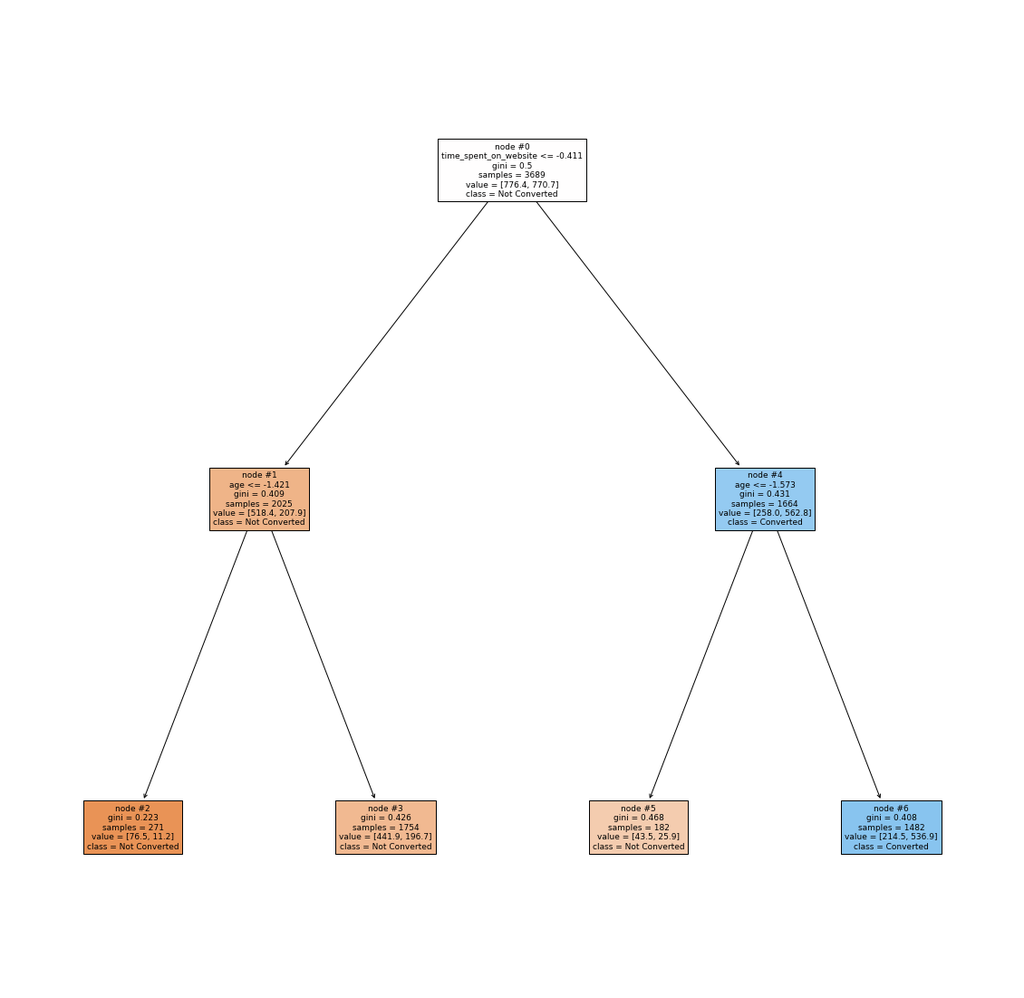

```python
from sklearn.tree import plot_tree
import matplotlib.pyplot as plt

plt.figure(figsize=(20, 20))
plot_tree(
    d_tree_tuned,
    feature_names=X_train.columns,
    class_names=["Not Converted", "Converted"],
    filled=True,
    fontsize=9,
    node_ids=True
)
plt.show()
```